# 4-2. 데이터 분석 1차 - 라벨링

각 포지션 별로 해당 포지션에 유의미하다고 판단되는 일부 컬럼들의 값을 기준으로 세우고, 이에 맞춰 챔피언을 분류하여 라벨링한다. 이때 분류는 해당 데이터로 클러스터링 한 결과에 따른다.

분류 대상은 라인별로 전체 픽률 0.5% 이상인 챔피언만으로 진행하며, 나머지 챔피언의 경우는 분류를 하지 않고 일괄적으로 비주류픽으로 분류한다.

```python
import pandas as pd
import numpy as np
import matplotlib.pyplot as plt
import seaborn as sns
# 경고메세지 무시
import warnings
warnings.filterwarnings('ignore')
```

```python
# # 모든 행 출력
# pd.set_option('display.max_rows',None)
```

```python
import pickle

with open("dataV3_processed.pickle","rb") as fr:
    df = pickle.load(fr)
df.head()
```

| matchId | gameDuration | assists | championName | damageDealtToObjectives | damageDealtToTurrets | damageSelfMitigated | deaths | dragonKills | kills | magicDamageDealtToChampions | ... | teamPosition | timeCCingOthers | totalDamageDealtToChampions | totalDamageShieldedOnTeammates | totalDamageTaken | totalHealsOnTeammates | totalMinionsKilled | trueDamageDealtToChampions | visionScore | win |
| --- | --- | --- | --- | --- | --- | --- | --- | --- | --- | --- | --- | --- | --- | --- | --- | --- | --- | --- | --- | --- | --- |
| KR_5944529373 | 1548 | 2 | Trundle | 10809 | 8068 | 14206 | 4 | 1 | 4 | 2200 | ... | TOP | 16 | 17912 | 0 | 22268 | 0 | 199 | 1251 | 11 | False |
| KR_5944529373 | 1548 | 5 | Viego | 12425 | 647 | 13265 | 5 | 0 | 3 | 1112 | ... | JUNGLE | 14 | 10543 | 0 | 20618 | 0 | 37 | 799 | 24 | False |
| KR_5944529373 | 1548 | 1 | Katarina | 4894 | 0 | 13089 | 6 | 0 | 7 | 14299 | ... | MIDDLE | 1 | 19362 | 0 | 22430 | 0 | 142 | 426 | 20 | False |
| KR_5944529373 | 1548 | 2 | Tristana | 334 | 248 | 8841 | 6 | 0 | 5 | 1986 | ... | BOTTOM | 2 | 10721 | 0 | 19263 | 0 | 168 | 588 | 24 | False |
| KR_5944529373 | 1548 | 9 | Nautilus | 5165 | 0 | 21768 | 7 | 0 | 0 | 4585 | ... | UTILITY | 59 | 7656 | 536 | 19286 | 0 | 32 | 461 | 48 | False |

5 rows × 22 columns

```python
df.columns # 컬럼명 확인
```

```
Index(['gameDuration', 'assists', 'championName', 'damageDealtToObjectives',
       'damageDealtToTurrets', 'damageSelfMitigated', 'deaths', 'dragonKills',
       'kills', 'magicDamageDealtToChampions', 'neutralMinionsKilled',
       'physicalDamageDealtToChampions', 'teamPosition', 'timeCCingOthers',
       'totalDamageDealtToChampions', 'totalDamageShieldedOnTeammates',
       'totalDamageTaken', 'totalHealsOnTeammates', 'totalMinionsKilled',
       'trueDamageDealtToChampions', 'visionScore', 'win'],
      dtype='object')
```

### 1. 탑 분류 기준

1. 1분당 가한 데미지와 받은 데미지(탱커 vs 딜러)
2. 1분당 가한 물리데미지와 마법데미지(물리 vs 마법)
3. 1분당 포탑에 가한 피해량, 챔프에 가한 총 피해량(한타참여형 vs 스플릿푸셔)

```python
# 포지션이 탑인 행만 선택
df_top = df[df['teamPosition']=='TOP']
df_top.head()
```

| matchId | gameDuration | assists | championName | damageDealtToObjectives | damageDealtToTurrets | damageSelfMitigated | deaths | dragonKills | kills | magicDamageDealtToChampions | ... | teamPosition | timeCCingOthers | totalDamageDealtToChampions | totalDamageShieldedOnTeammates | totalDamageTaken | totalHealsOnTeammates | totalMinionsKilled | trueDamageDealtToChampions | visionScore | win |
| --- | --- | --- | --- | --- | --- | --- | --- | --- | --- | --- | --- | --- | --- | --- | --- | --- | --- | --- | --- | --- | --- |
| KR_5944529373 | 1548 | 2 | Trundle | 10809 | 8068 | 14206 | 4 | 1 | 4 | 2200 | ... | TOP | 16 | 17912 | 0 | 22268 | 0 | 199 | 1251 | 11 | False |
| KR_5944529373 | 1548 | 4 | Gwen | 10842 | 6365 | 15666 | 3 | 0 | 6 | 7393 | ... | TOP | 5 | 14367 | 0 | 18134 | 0 | 163 | 3961 | 16 | True |
| KR_5944532797 | 1858 | 8 | Olaf | 9360 | 9360 | 49735 | 7 | 0 | 11 | 222 | ... | TOP | 14 | 34440 | 0 | 32154 | 0 | 195 | 10330 | 11 | True |
| KR_5944532797 | 1858 | 2 | Garen | 6040 | 6040 | 32634 | 7 | 0 | 3 | 862 | ... | TOP | 20 | 12143 | 0 | 29997 | 0 | 197 | 4323 | 12 | False |
| KR_5944532993 | 2094 | 8 | Malphite | 3247 | 754 | 49377 | 5 | 0 | 2 | 13080 | ... | TOP | 32 | 15861 | 0 | 24626 | 0 | 176 | 683 | 27 | False |

5 rows × 22 columns

```python
total = len(df_top)/2
total # 총 게임수 확인
```

```
108504.0
```

```python
# 챔프별 픽률 계산
# 픽률 = 해당 챔프 선택된 게임 수 / 전체 게임수

df_topchamp = df_top['championName'].value_counts()
df_topchamp.head()
```

```
Aatrox       13651
Darius        8971
Gangplank     8761
Fiora         7882
Renekton      6712
Name: championName, dtype: int64
```

```python
df_topchamp = pd.DataFrame(df_topchamp) # 컬럼 추가 위해 DataFrame으로 변환
df_topchamp.columns = ['pickCount']
df_topchamp['pickRate'] = df_topchamp['pickCount']/total*100 # 픽률 계산
df_topchamp.head()
```

|  | pickCount | pickRate |
| --- | --- | --- |
| Aatrox | 13651 | 12.581103 |
| Darius | 8971 | 8.267898 |
| Gangplank | 8761 | 8.074357 |
| Fiora | 7882 | 7.264248 |
| Renekton | 6712 | 6.185947 |

```python
df_top_major = df_topchamp[df_topchamp['pickRate'] >= 0.5]
df_top_major.count() # 픽률 0.5% 이상인 챔프 수
```

```
pickCount    66
pickRate     66
dtype: int64
```

```python
# 챔프별 통계
df_top.groupby('championName').mean().head()
```

| championName | gameDuration | assists | damageDealtToObjectives | damageDealtToTurrets | damageSelfMitigated | deaths | dragonKills | kills | magicDamageDealtToChampions | neutralMinionsKilled | physicalDamageDealtToChampions | timeCCingOthers | totalDamageDealtToChampions | totalDamageShieldedOnTeammates | totalDamageTaken | totalHealsOnTeammates | totalMinionsKilled | trueDamageDealtToChampions | visionScore | win |
| --- | --- | --- | --- | --- | --- | --- | --- | --- | --- | --- | --- | --- | --- | --- | --- | --- | --- | --- | --- | --- |
| Aatrox | 1870.234781 | 0.721412 | 9732.444803 | 3359.149806 | 36468.403267 | 6.235587 | 0.079042 | 5.806901 | 85.311919 | 14.264669 | 22479.194491 | 23.385173 | 22966.852831 | 0.0 | 36167.877884 | 0.285327 | 180.908505 | 401.989232 | 19.938613 | 0.494103 |
| Ahri | 1931.901639 | 1.754098 | 5380.540984 | 2890.754098 | 12800.770492 | 6.163934 | 0.032787 | 5.081967 | 14386.721311 | 5.868852 | 1730.377049 | 23.754098 | 21143.278689 | 0.0 | 23751.803279 | 0.000000 | 185.245902 | 5025.114754 | 22.540984 | 0.409836 |
| Akali | 1896.761460 | 1.254960 | 4135.835348 | 2258.669327 | 20192.462942 | 6.280730 | 0.029647 | 7.397263 | 21266.350057 | 4.096921 | 1627.360775 | 2.052223 | 24388.775599 | 0.0 | 30254.386089 | 0.150285 | 173.928848 | 1494.233067 | 19.330217 | 0.447206 |
| Akshan | 1891.491379 | 1.623563 | 10480.949713 | 4760.790230 | 19535.660920 | 7.327586 | 0.097701 | 7.791667 | 3777.445402 | 12.622126 | 19730.636494 | 2.683908 | 25914.649425 | 0.0 | 24201.715517 | 0.000000 | 188.135057 | 2405.622126 | 23.043103 | 0.492816 |
| Alistar | 1853.413793 | 5.275862 | 3537.482759 | 1814.000000 | 54742.172414 | 6.000000 | 0.000000 | 2.413793 | 11842.103448 | 2.586207 | 2305.241379 | 65.344828 | 14938.965517 | 0.0 | 33645.000000 | 4414.344828 | 134.827586 | 790.724138 | 18.068966 | 0.517241 |

```python
# 챔프별 통계에서 픽률 기준 충족하는 행만 선택
df_top_major = df_top.groupby('championName').mean().loc[df_top_major.index]
df_top_major
```

|  | gameDuration | assists | damageDealtToObjectives | damageDealtToTurrets | damageSelfMitigated | deaths | dragonKills | kills | magicDamageDealtToChampions | neutralMinionsKilled | physicalDamageDealtToChampions | timeCCingOthers | totalDamageDealtToChampions | totalDamageShieldedOnTeammates | totalDamageTaken | totalHealsOnTeammates | totalMinionsKilled | trueDamageDealtToChampions | visionScore | win |
| --- | --- | --- | --- | --- | --- | --- | --- | --- | --- | --- | --- | --- | --- | --- | --- | --- | --- | --- | --- | --- |
| Aatrox | 1870.234781 | 0.721412 | 9732.444803 | 3359.149806 | 36468.403267 | 6.235587 | 0.079042 | 5.806901 | 85.311919 | 14.264669 | 22479.194491 | 23.385173 | 22966.852831 | 0.000000 | 36167.877884 | 0.285327 | 180.908505 | 401.989232 | 19.938613 | 0.494103 |
| Darius | 1880.580091 | 1.059748 | 11901.146026 | 5460.135771 | 34540.040241 | 6.271988 | 0.104002 | 7.403077 | 112.696801 | 12.584885 | 16251.533608 | 21.970572 | 20772.165756 | 0.000000 | 30230.423364 | 0.096868 | 194.973024 | 4407.272656 | 20.994426 | 0.511426 |
| Gangplank | 1905.604497 | 2.072937 | 13123.297226 | 5764.854925 | 21176.821938 | 6.558840 | 0.104668 | 6.542061 | 4619.630065 | 12.081383 | 17785.562607 | 12.236389 | 27111.787467 | 0.000000 | 29129.407830 | 0.929803 | 210.037210 | 4705.597078 | 21.265267 | 0.482365 |
| Fiora | 1874.762624 | 1.237503 | 11449.354732 | 7535.282796 | 36401.494164 | 6.555062 | 0.059756 | 6.267064 | 1304.274930 | 10.971454 | 14762.044532 | 11.153261 | 23605.335194 | 0.288379 | 35420.680665 | 1772.062421 | 194.992895 | 7538.013575 | 19.912839 | 0.505582 |
| Renekton | 1886.284863 | 0.928039 | 10785.429678 | 5273.594756 | 33397.196216 | 6.544696 | 0.086561 | 6.051400 | 3017.377831 | 13.247318 | 17892.561830 | 22.266836 | 21852.827473 | 0.000000 | 35050.112038 | 0.142282 | 196.799017 | 942.056466 | 21.073153 | 0.478993 |
| ... | ... | ... | ... | ... | ... | ... | ... | ... | ... | ... | ... | ... | ... | ... | ... | ... | ... | ... | ... | ... |
| Chogath | 1907.406609 | 1.810345 | 9241.580460 | 3534.979885 | 47219.293103 | 5.943966 | 0.402299 | 5.969828 | 14268.477011 | 11.867816 | 2591.264368 | 84.908046 | 20874.377874 | 3.362069 | 39221.656609 | 30.369253 | 180.196839 | 4013.596264 | 20.077586 | 0.505747 |
| Akshan | 1891.491379 | 1.623563 | 10480.949713 | 4760.790230 | 19535.660920 | 7.327586 | 0.097701 | 7.791667 | 3777.445402 | 12.622126 | 19730.636494 | 2.683908 | 25914.649425 | 0.000000 | 24201.715517 | 0.000000 | 188.135057 | 2405.622126 | 23.043103 | 0.492816 |
| Pantheon | 1887.334928 | 1.797448 | 7850.328549 | 3099.706539 | 24452.406699 | 7.287081 | 0.113238 | 7.437002 | 1115.998405 | 10.408293 | 21657.192982 | 23.880383 | 23929.315789 | 0.000000 | 27608.103668 | 2.660287 | 159.629984 | 1155.259968 | 19.862839 | 0.475279 |
| Cassiopeia | 1909.720137 | 1.860068 | 11511.474403 | 2832.559727 | 16791.523891 | 7.003413 | 0.163823 | 7.023891 | 24795.569966 | 18.245734 | 485.889078 | 36.621160 | 25753.510239 | 0.000000 | 28582.668942 | 0.000000 | 197.952218 | 471.349829 | 24.930034 | 0.510239 |
| XinZhao | 1864.252669 | 1.309609 | 12713.672598 | 6001.795374 | 27625.265125 | 7.994662 | 0.128114 | 7.542705 | 1403.928826 | 16.081851 | 22593.786477 | 22.834520 | 25429.046263 | 0.000000 | 30248.243772 | 0.000000 | 174.610320 | 1430.471530 | 18.128114 | 0.517794 |

66 rows × 20 columns

#### 1-a. 1분당 가한 데미지와 받은 데미지(탱커 vs 딜러)

```python
# 1분당 가한데미지 = (totalDamageDealtToChampions / gameDuration) * 60
df_top_major['dpm'] = df_top_major['totalDamageDealtToChampions']/df_top_major['gameDuration']*60

# 1분당 받은 데미지 = (damageSelfMitigated + totalDamageTaken)/gameDuration * 60
df_top_major['dtpm'] = (df_top_major['damageSelfMitigated']+df_top_major['totalDamageTaken'])/df_top_major['gameDuration']*60

df_top_major[['dpm','dtpm']].head()
```

|  | dpm | dtpm |
| --- | --- | --- |
| Aatrox | 736.811861 | 2330.283295 |
| Darius | 662.736967 | 2066.504816 |
| Gangplank | 853.643687 | 1583.945562 |
| Fiora | 755.466369 | 2298.600599 |
| Renekton | 695.106913 | 2177.210121 |

```python
from sklearn.preprocessing import StandardScaler
from sklearn.cluster import KMeans
from sklearn.metrics import silhouette_score
```

```
실루엣 스코어: 0.5333425811363812
----------라벨 0----------
군집 중심: [-0.70509736  0.69613063]
해당 챔피언 목록
['Aatrox', 'Darius', 'Fiora', 'Renekton', 'Camille', 'Sett', 'Mordekaiser', 'Ornn', 'Jax', 'Shen', 'Malphite', 'Garen', 'Gragas', 'Shyvana', 'Maokai', 'Volibear', 'Sejuani', 'Riven', 'Udyr', 'Nasus', 'Poppy', 'Warwick', 'DrMundo', 'Rengar', 'Zac', 'Sion', 'Tryndamere', 'Kled', 'Yasuo', 'TahmKench', …
----------라벨 1----------
군집 중심: [ 0.79607767 -0.78595394]
해당 챔피언 목록
['Gangplank', 'Irelia', 'Gnar', 'Jayce', 'Yone', 'Akali', 'Gwen', 'Kayle', 'Teemo', 'Vayne', 'Illaoi', 'Rumble', 'Sylas', 'Lillia', 'Kennen', 'Olaf', 'Yorick', 'Vladimir', 'Quinn', 'Swain', 'Heimerdinger', 'Ryze', 'Viktor', 'Kayn', 'Kalista', 'Graves', 'Lucian', 'Akshan', 'Pantheon', 'Cassiopeia', '…
```

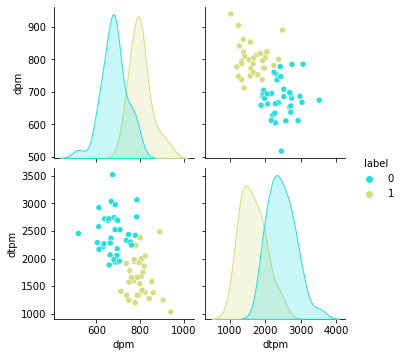

```python
# dpm, dtpm으로 군집 분석 및 시각화

# 데이터 정규화(z-score)
scaler = StandardScaler()
x = scaler.fit_transform(df_top_major[['dpm','dtpm']]) #

# k-means
km = KMeans(n_clusters=2, random_state=0)
km_data = km.fit_transform(x)
print('실루엣 스코어:',silhouette_score(km_data, km.labels_))
labels = pd.DataFrame(data={'label':km.labels_}, index=df_top_major.index) # 라벨링 결과 챔피언과 조인

for j in range(0,2):
    print('-'*10+'라벨 '+str(j)+'-'*10)
    print('군집 중심:',km.cluster_centers_[j])
    print('해당 챔피언 목록')
    print(labels[labels['label']==j].index.to_list())

res = pd.concat([labels, df_top_major[['dpm','dtpm']]], axis=1) # 결과 시각화 위해 조인
sns.pairplot(res, hue='label', palette='rainbow') # dpm, dtpm을 두 축으로 페어플롯
plt.show()
```

#### 결과 평가

- 관용적인 관점에서 라벨0은 탱커로, 라벨1은 딜러로 인식되던 챔프들
- 양 군집 모두 군집 내에서도 챔프간의 성능 차이가 다소 존재하나, 매크로한 관점에선 각각 탱커나 딜러로 분류해도 받아들일 수 있는 수준

```python
# 라벨링 결과 누적
label_top = labels.copy()
label_top['top_tank'] = (label_top['label']==0)*1 # 탱커면 0
label_top['top_deal'] = (label_top['label']==1)*1 # 딜러면 1
label_top.drop('label',axis=1,inplace=True)
label_top.head()
```

|  | top_tank | top_deal |
| --- | --- | --- |
| Aatrox | 1 | 0 |
| Darius | 1 | 0 |
| Gangplank | 0 | 1 |
| Fiora | 1 | 0 |
| Renekton | 1 | 0 |

#### 1-2. 1분당 가한 물리데미지와 마법데미지(물리 vs 마법)

```python
# 1분당 가한 물리데미지 = (physicalDamageDealtToChampions / gameDuration) * 60
df_top_major['pdpm'] = df_top_major['physicalDamageDealtToChampions']/df_top_major['gameDuration']*60

# 1분당 가한 마법데미지 = magicDamageDealtToChampions / gameDuration * 60
df_top_major['mdpm'] = (df_top_major['magicDamageDealtToChampions']+df_top_major['totalDamageTaken'])/df_top_major['gameDuration']*60

df_top_major[['pdpm','mdpm']].head()
```

|  | pdpm | mdpm |
| --- | --- | --- |
| Aatrox | 721.167034 | 1163.057927 |
| Darius | 518.505976 | 968.098736 |
| Gangplank | 559.997501 | 1062.624630 |
| Fiora | 472.445237 | 1175.347379 |
| Renekton | 569.136577 | 1210.871930 |

```
실루엣 스코어: 0.7188169984383573
----------라벨 0----------
군집 중심: [ 0.8639115  -0.79128146]
해당 챔피언 목록
['Aatrox', 'Darius', 'Gangplank', 'Fiora', 'Renekton', 'Irelia', 'Gnar', 'Camille', 'Sett', 'Jayce', 'Yone', 'Jax', 'Garen', 'Vayne', 'Riven', 'Illaoi', 'Nasus', 'Olaf', 'Yorick', 'Poppy', 'Rengar', 'Tryndamere', 'Kled', 'Yasuo', 'Quinn', 'MonkeyKing', 'Urgot', 'Kayn', 'Trundle', 'Kalista', 'Graves'…
----------라벨 1----------
군집 중심: [-0.97538396  0.89338229]
해당 챔피언 목록
['Mordekaiser', 'Ornn', 'Akali', 'Gwen', 'Shen', 'Malphite', 'Kayle', 'Gragas', 'Teemo', 'Shyvana', 'Maokai', 'Volibear', 'Sejuani', 'Rumble', 'Sylas', 'Lillia', 'Udyr', 'Kennen', 'Warwick', 'DrMundo', 'Vladimir', 'Zac', 'Sion', 'TahmKench', 'Singed', 'Swain', 'Heimerdinger', 'Ryze', 'Viktor', 'Chog…
```

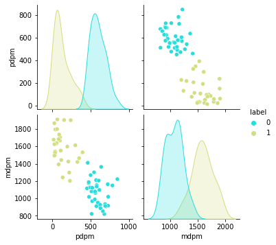

```python
# pdpm, mdpm으로 군집 분석 및 시각화

# 데이터 정규화(z-score)
scaler = StandardScaler()
x = scaler.fit_transform(df_top_major[['pdpm','mdpm']]) #

# k-means
km = KMeans(n_clusters=2, random_state=0)
km_data = km.fit_transform(x)
print('실루엣 스코어:',silhouette_score(km_data, km.labels_))
labels = pd.DataFrame(data={'label':km.labels_}, index=df_top_major.index) # 라벨링 결과 챔피언과 조인

for j in range(0,2):
    print('-'*10+'라벨 '+str(j)+'-'*10)
    print('군집 중심:',km.cluster_centers_[j])
    print('해당 챔피언 목록')
    print(labels[labels['label']==j].index.to_list())

res = pd.concat([labels, df_top_major[['pdpm','mdpm']]], axis=1) # 결과 시각화 위해 조인
sns.pairplot(res, hue='label', palette='rainbow') # pdpm, mdpm을 두 축으로 페어플롯
plt.show()
```

#### 결과 평가

- 관용적인 관점에서 라벨0은 물리 기반, 라벨1은 마법 기반 데미지로 인식되던 챔프들
- 실루엣 스코어는 앞선 탱/딜 분류에서의 0.53보다 향상된 0.72로 더 명확히 구분되었다고 판단됨
- 실제로 앞선 데이터 탐색에서 마법/물리 데미지 분류는 명확하게 구분되는 경향을 확인하였음

```python
# 라벨링 결과 누적
label_top = pd.concat([label_top, labels], axis=1)
label_top['top_ap'] = (label_top['label']==1)*1 # ap면 1
label_top['top_ad'] = (label_top['label']==0)*1 # ad면 0
label_top.drop('label',axis=1,inplace=True)
label_top.head()
```

|  | top_tank | top_deal | top_ap | top_ad |
| --- | --- | --- | --- | --- |
| Aatrox | 1 | 0 | 0 | 1 |
| Darius | 1 | 0 | 0 | 1 |
| Gangplank | 0 | 1 | 0 | 1 |
| Fiora | 1 | 0 | 0 | 1 |
| Renekton | 1 | 0 | 0 | 1 |

#### 1-3. 1분당 포탑에 가한 피해량, 챔프에 가한 총 피해량(한타참여형 vs 스플릿푸셔)

```python
# 1분당 포탑에 가한 피해량 = (damageDealtToTurrets / gameDuration) * 60
df_top_major['ddt'] = df_top_major['damageDealtToTurrets']/df_top_major['gameDuration']*60

# 1분당 챔피언에 가한 피핼먕 = totalDamageDealtToChampions / gameDuration * 60
df_top_major['dpm'] = df_top_major['totalDamageDealtToChampions']/df_top_major['gameDuration']*60

df_top_major[['ddt','dpm']].head()
```

|  | ddt | dpm |
| --- | --- | --- |
| Aatrox | 107.766677 | 736.811861 |
| Darius | 174.205899 | 662.736967 |
| Gangplank | 181.512636 | 853.643687 |
| Fiora | 241.159580 | 755.466369 |
| Renekton | 167.745441 | 695.106913 |

```
실루엣 스코어: 0.41099198544036336
----------라벨 0----------
군집 중심: [-0.75490994 -0.3503591 ]
해당 챔피언 목록
['Aatrox', 'Gnar', 'Mordekaiser', 'Yone', 'Ornn', 'Akali', 'Shen', 'Malphite', 'Gragas', 'Shyvana', 'Maokai', 'Volibear', 'Sejuani', 'Riven', 'Rumble', 'Sylas', 'Lillia', 'Udyr', 'Kennen', 'Poppy', 'Warwick', 'Vladimir', 'Zac', 'Sion', 'Yasuo', 'TahmKench', 'Singed', 'Swain', 'MonkeyKing', 'Ryze', '…
----------라벨 1----------
군집 중심: [0.80209181 0.37225655]
해당 챔피언 목록
['Darius', 'Gangplank', 'Fiora', 'Renekton', 'Irelia', 'Camille', 'Sett', 'Jayce', 'Jax', 'Gwen', 'Garen', 'Kayle', 'Teemo', 'Vayne', 'Illaoi', 'Nasus', 'Olaf', 'Yorick', 'DrMundo', 'Rengar', 'Tryndamere', 'Kled', 'Quinn', 'Heimerdinger', 'Viktor', 'Urgot', 'Trundle', 'Kalista', 'Graves', 'Lucian', …
```

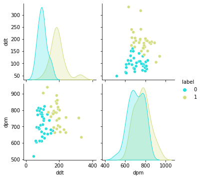

```python
# ddt, dpm으로 군집 분석 및 시각화

# 데이터 정규화(z-score)
scaler = StandardScaler()
x = scaler.fit_transform(df_top_major[['ddt','dpm']]) #

# k-means
km = KMeans(n_clusters=2, random_state=0)
km_data = km.fit_transform(x)
print('실루엣 스코어:',silhouette_score(km_data, km.labels_))
labels = pd.DataFrame(data={'label':km.labels_}, index=df_top_major.index) # 라벨링 결과 챔피언과 조인

for j in range(0,2):
    print('-'*10+'라벨 '+str(j)+'-'*10)
    print('군집 중심:',km.cluster_centers_[j])
    print('해당 챔피언 목록')
    print(labels[labels['label']==j].index.to_list())

res = pd.concat([labels, df_top_major[['ddt','dpm']]], axis=1) # 결과 시각화 위해 조인
sns.pairplot(res, hue='label', palette='rainbow') # pdpm, mdpm을 두 축으로 페어플롯
plt.show()
```

#### 결과 평가

- 관용적인 관점에서 라벨0은 한타 참여를 선호하는 챔프, 라벨1은 스플릿 푸시 운영을 즐기는 챔프
- 실루엣 스코어는 0.41로 앞선 분류들에 비해 다소 불명확하다고 판단됨
- 경계에 애매한 챔프들이 몇몇 있으나 분류에 오류가 있다고 할 수준은 아님

```python
# 라벨링 결과 누적
label_top = pd.concat([label_top, labels], axis=1)
label_top['top_sp'] = (label_top['label']==1)*1 # 스플릿 푸셔: 1
label_top['top_tf'] = (label_top['label']==0)*1 # 한타 참여형: 0
label_top.drop('label',axis=1,inplace=True)
label_top.head()
```

|  | top_tank | top_deal | top_ap | top_ad | top_sp | top_tf |
| --- | --- | --- | --- | --- | --- | --- |
| Aatrox | 1 | 0 | 0 | 1 | 0 | 1 |
| Darius | 1 | 0 | 0 | 1 | 1 | 0 |
| Gangplank | 0 | 1 | 0 | 1 | 1 | 0 |
| Fiora | 1 | 0 | 0 | 1 | 1 | 0 |
| Renekton | 1 | 0 | 0 | 1 | 1 | 0 |

```python
df_topchamp['top_minor'] = 1 # 비주류픽 여부
df_topchamp.loc[df_top_major.index,'top_minor'] = 0 # 주류 픽인 경우 0 대입
df_topchamp
```

|  | pickCount | pickRate | top_minor |
| --- | --- | --- | --- |
| Aatrox | 13651 | 12.581103 | 0 |
| Darius | 8971 | 8.267898 | 0 |
| Gangplank | 8761 | 8.074357 | 0 |
| Fiora | 7882 | 7.264248 | 0 |
| Renekton | 6712 | 6.185947 | 0 |
| ... | ... | ... | ... |
| Braum | 5 | 0.004608 | 1 |
| Janna | 5 | 0.004608 | 1 |
| Yuumi | 5 | 0.004608 | 1 |
| Sona | 5 | 0.004608 | 1 |
| Rakan | 4 | 0.003687 | 1 |

160 rows × 3 columns

```python
# 비주류여부 컨캣 후 null을 0으로 치환
label_top = pd.concat([df_topchamp.drop(['pickCount','pickRate'],axis=1),label_top],axis=1)
label_top[label_top.isnull()] = 0
label_top
```

|  | top_minor | top_tank | top_deal | top_ap | top_ad | top_sp | top_tf |
| --- | --- | --- | --- | --- | --- | --- | --- |
| Aatrox | 0 | 1.0 | 0.0 | 0.0 | 1.0 | 0.0 | 1.0 |
| Darius | 0 | 1.0 | 0.0 | 0.0 | 1.0 | 1.0 | 0.0 |
| Gangplank | 0 | 0.0 | 1.0 | 0.0 | 1.0 | 1.0 | 0.0 |
| Fiora | 0 | 1.0 | 0.0 | 0.0 | 1.0 | 1.0 | 0.0 |
| Renekton | 0 | 1.0 | 0.0 | 0.0 | 1.0 | 1.0 | 0.0 |
| ... | ... | ... | ... | ... | ... | ... | ... |
| Braum | 1 | 0.0 | 0.0 | 0.0 | 0.0 | 0.0 | 0.0 |
| Janna | 1 | 0.0 | 0.0 | 0.0 | 0.0 | 0.0 | 0.0 |
| Yuumi | 1 | 0.0 | 0.0 | 0.0 | 0.0 | 0.0 | 0.0 |
| Sona | 1 | 0.0 | 0.0 | 0.0 | 0.0 | 0.0 | 0.0 |
| Rakan | 1 | 0.0 | 0.0 | 0.0 | 0.0 | 0.0 | 0.0 |

160 rows × 7 columns

```python
# 탑 라벨링 결과 피클로 저장
with open("label_top.pickle","wb") as fw:
    pickle.dump(label_top, fw)
```

위와 동일한 과정을 포지션별로 반복하여 진행, 각 포지션별 챔피언들을 모두 라벨링 한 결과는 아래와 같다.

포지션 별로 게임 내용을 평가하는 지표는 아래에 서술한다.

분류과정과 코드, 시각화 차트는 위와 유사하므로 생략한다.

### 2. 정글 분류 기준

1. 탱커/딜러 분류 (tank/deal)
2. 물리/마법 분류 (ad/hy/ap)
3. 초반 운영스타일(공격적-agg/중립적-neu/수동적-pas) 분류 - 퍼스트블러드 관여율로 판단

코드는 위와 유사하므로 생략

```python
with open("label_jgl.pickle","rb") as fr:
    label_jgl = pickle.load(fr)
label_jgl.head()
```

|  | jgl_비주류 | jgl_ad | jgl_ap | jgl_hy | jgl_agg | jgl_pas | jgl_neu | jgl_tank | jgl_deal |
| --- | --- | --- | --- | --- | --- | --- | --- | --- | --- |
| Amumu | 0 | 0 | 1 | 0 | 0 | 0 | 1 | 1 | 0 |
| Belveth | 0 | 1 | 0 | 0 | 0 | 0 | 1 | 1 | 0 |
| Diana | 0 | 0 | 1 | 0 | 0 | 1 | 0 | 0 | 1 |
| Ekko | 0 | 0 | 1 | 0 | 0 | 1 | 0 | 0 | 1 |
| Elise | 0 | 0 | 1 | 0 | 1 | 0 | 0 | 0 | 1 |

### 3. 미드 분류 기준

1. 탱커/딜러 분류 (tank/deal)
2. 물리/마법 분류 (ad/ap)
3. 플레이 스타일(플레이메이킹-maker/암살자-killer/성장형-farmer/공격적라인전-aggres) 분류 - kill, death, assist, cs/m(분당 미니언 처치수)로 판단

코드는 위와 유사하므로 생략

```python
with open("label_mid.pickle","rb") as fr:
    label_mid = pickle.load(fr)
label_mid.head()
```

|  | mid_비주류 | mid_ad | mid_ap | mid_maker | mid_killer | mid_farmer | mid_aggres | mid_tank | mid_deal |
| --- | --- | --- | --- | --- | --- | --- | --- | --- | --- |
| Aatrox | 0 | 1 | 0 | 0 | 1 | 0 | 0 | 1 | 0 |
| Ahri | 0 | 0 | 1 | 1 | 0 | 0 | 0 | 0 | 1 |
| Akali | 0 | 0 | 1 | 0 | 1 | 0 | 0 | 1 | 0 |
| Akshan | 0 | 1 | 0 | 0 | 1 | 0 | 0 | 0 | 1 |
| Anivia | 0 | 0 | 1 | 0 | 0 | 1 | 0 | 0 | 1 |

### 4. 바텀 분류 기준

코드는 위와 유사하므로 생략

```python
with open("label_bot.pickle","rb") as fr:
    label_bot = pickle.load(fr)
label_bot.head()
```

|  | bot_비주류 | bot_ad | bot_ap | bot_outboxer | bot_rush | bot_infight |
| --- | --- | --- | --- | --- | --- | --- |
| Aphelios | 0 | 1 | 0 | 1 | 0 | 0 |
| Ashe | 0 | 1 | 0 | 1 | 0 | 0 |
| Caitlyn | 0 | 1 | 0 | 1 | 0 | 0 |
| Draven | 0 | 1 | 0 | 0 | 0 | 1 |
| Ezreal | 0 | 1 | 0 | 1 | 0 | 0 |

### 5. 서폿 분류 기준

1. 플레이 스타일(유틸-util/탱커-tank/딜러-deal)분류 - 시야점수, 힐+실드량, 가한데미지, 받은데미지
2. 스타일이 딜러인 경우(ap/ad) - 마법데미지, 물리데미지

코드는 위와 유사하므로 생략

```python
with open("label_sup.pickle","rb") as fr:
    label_sup = pickle.load(fr)
label_sup.head()
```

|  | sup_비주류 | sup_util | sup_tank | sup_deal_ap | sup_deal_ad |
| --- | --- | --- | --- | --- | --- |
| Ezreal | 1 | 0 | 0 | 0 | 0 |
| Kaisa | 1 | 0 | 0 | 0 | 0 |
| LeeSin | 1 | 0 | 0 | 0 | 0 |
| Sylas | 0 | 0 | 0 | 1 | 0 |
| Ashe | 0 | 0 | 0 | 0 | 1 |

다음 과정에서 위의 포지션별 챔피언의 라벨링결과를 적용하여 머신러닝 모델에 학습을 진행한다.